# Coding Assignment 3

Team 11

Due: 2021-12-09 23:59

A Florida health insurance company wants to predict annual claims for individual clients. The company pulls a random sample of 50 customers. The owner wishes to charge an actuarially fair premium to ensure a normal rate of return. The owner collects all of their current customer’s health care expenses from the last year and compares them with what is known about each customer’s plan.

The data on the 50 customers in the sample is as follows:

- Charges: Total medical expenses for a particular insurance plan (in dollars)
- Age: Age of the primary beneficiary
- BMI: Primary beneficiary’s body mass index (kg/m2)
- Female: Primary beneficiary’s birth sex (0 = Male, 1 = Female)
- Children: Number of children covered by health insurance plan (includes other dependents as well)
- Smoker: Indicator if primary beneficiary is a smoker (0 = non-smoker, 1 = smoker)
- Cities: Dummy variables for each city with the default being Sanford

Answer the following questions using complete sentences and attach all output, plots, etc. within this report.

## Question 1

Randomly select three observations from the sample and exclude from all modeling (i.e. n=47). Provide the summary statistics (min, max, std, mean, median) of the quantitative variables for the 47 observations.

```r
set.seed(123457)
insuranceremove3 <- insurance[-sample(1:nrow(insurance), 3), ]
removequalitative1 <- insuranceremove3[,c('Charges','Age','BMI','Children')]

sd(removequalitative1$Charges, na.rm = TRUE)
```

```
## [1] 10123.25
```

```r
sd(removequalitative1$Age, na.rm = TRUE)
```

```
## [1] 14.20385
```

```r
sd(removequalitative1$BMI, na.rm = TRUE)
```

```
## [1] 6.303552
```

```r
sd(removequalitative1$Children, na.rm = TRUE)
```

```
## [1] 1.201679
```

```r
index <- sample(seq_len(nrow(insuranceremove3)), size = 3)
train <- insuranceremove3[-index,]
test <- insuranceremove3[index,]



train %>%
  tbl_summary(statistic = list(all_continuous() ~ c("{mean} ({sd})",
                                                    "{median} ({p25}, {p75})",
                                                    "{min}, {max}"),
                              all_categorical() ~ "{n} / {N} ({p}%)"),
              type = all_continuous() ~ "continuous2")
```

| **Characteristic** | **N = 44**<sup>1</sup> |
| --- | --- |
| Charges |  |
| Mean (SD) | 11,162 (10,405) |
| Median (IQR) | 7,168 (4,322, 13,311) |
| Range | 1,243, 45,702 |
| Age |  |
| Mean (SD) | 39 (14) |
| Median (IQR) | 38 (26, 50) |
| Range | 18, 64 |
| BMI |  |
| Mean (SD) | 30 (6) |
| Median (IQR) | 29 (26, 33) |
| Range | 17, 43 |
| Female | 23 / 44 (52%) |
| Children |  |
| 0 | 18 / 44 (41%) |
| 1 | 9 / 44 (20%) |
| 2 | 12 / 44 (27%) |
| 3 | 3 / 44 (6.8%) |
| 4 | 2 / 44 (4.5%) |
| Smoker | 5 / 44 (11%) |
| WinterSprings | 10 / 44 (23%) |
| WinterPark | 10 / 44 (23%) |
| Oviedo | 8 / 44 (18%) |

<sup>1</sup> n / N (%)

## Question 2

Provide the correlation between all quantitative variables

```r
cor(removequalitative1)
```

```
##            Charges        Age       BMI   Children
## Charges  1.0000000 0.40668426 0.2809465 0.10982770
## Age      0.4066843 1.00000000 0.0537894 0.02059507
## BMI      0.2809465 0.05378940 1.0000000 0.12796073
## Children 0.1098277 0.02059507 0.1279607 1.00000000
```

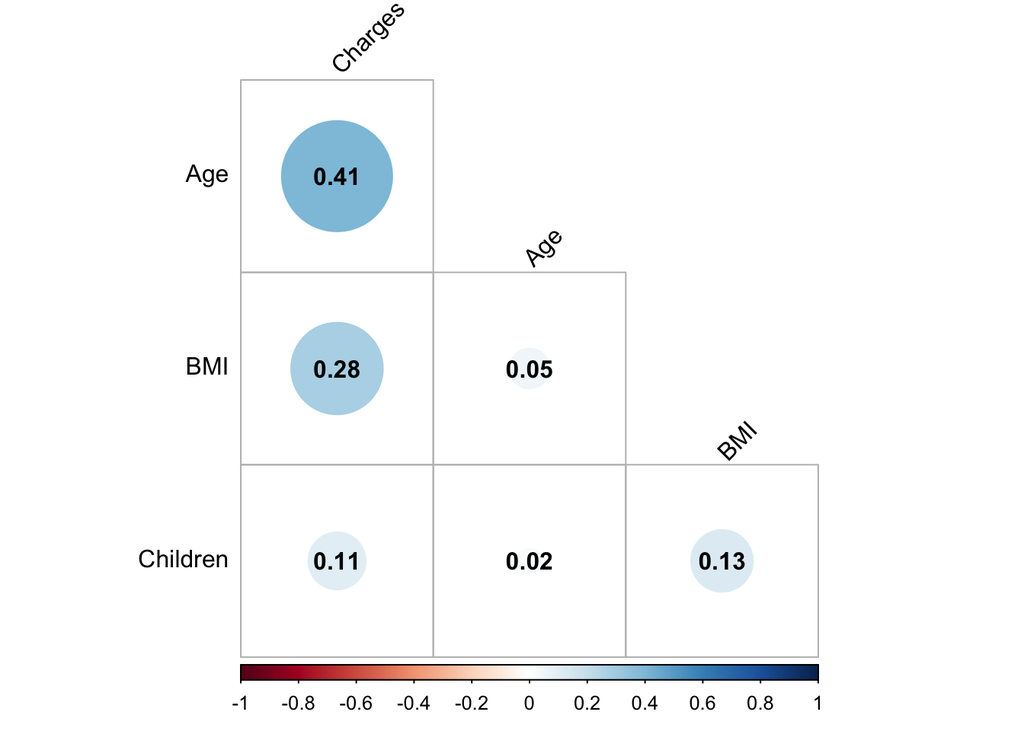

```r
corrplot(cor(removequalitative1),
type = "lower",
order = "hclust",
tl.col = "black",
tl.srt = 45,
addCoef.col = "black",
diag = FALSE)
```

The quantitative variables are Charges, Age, BMI, Children. The correlation between all quantitative variables is shown above. Based on the data above, Age is positively correlated to Charges. As well as, BMI and Charges, Children and Charges. Insurance Premiums would increase based on an increase in age, BMI and to some small degree the number of children you have.

## Question 3

Run a regression that includes all independent variables in the data table. Does the model above violate any of the Gauss-Markov assumptions? If so, what are they and what is the solution for correcting?

```r
model <- lm(Charges~ Age + BMI + Female + Children + Smoker +WinterSprings + WinterPark + Oviedo, data = insuranceremove3)
summary(model)
```

```
##
## Call:
## lm(formula = Charges ~ Age + BMI + Female + Children + Smoker +
##     WinterSprings + WinterPark + Oviedo, data = insuranceremove3)
##
## Residuals:
##     Min      1Q  Median      3Q     Max
## -8097.0 -2816.0  -833.3  1299.2 16597.4
##
## Coefficients:
##                Estimate Std. Error t value Pr(>|t|)
## (Intercept)   -10562.11    4330.65  -2.439  0.01951 *
## Age              228.91      52.23   4.383 8.94e-05 ***
## BMI              357.59     119.86   2.983  0.00496 **
## Female          -934.12    1577.27  -0.592  0.55720
## Children         835.30     680.73   1.227  0.22734
## Smoker         24141.19    2506.00   9.633 9.54e-12 ***
## WinterSprings     97.83    2089.80   0.047  0.96291
## WinterPark     -3892.00    1961.23  -1.984  0.05446 .
## Oviedo         -1311.73    2238.58  -0.586  0.56136
## ---
## Signif. codes:  0 '***' 0.001 '**' 0.01 '*' 0.05 '.' 0.1 ' ' 1
##
## Residual standard error: 4932 on 38 degrees of freedom
## Multiple R-squared:  0.8039, Adjusted R-squared:  0.7626
## F-statistic: 19.47 on 8 and 38 DF,  p-value: 2.993e-11
```

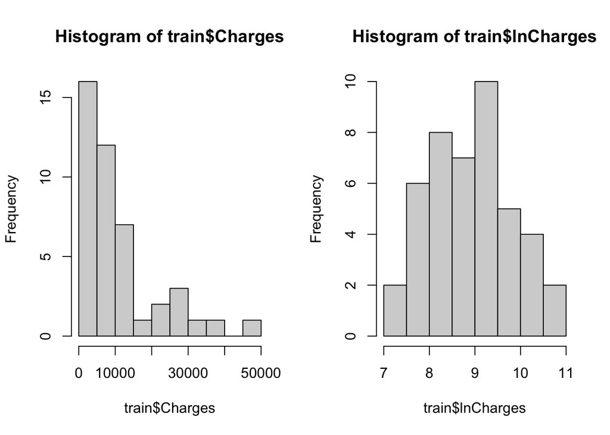

```r
par(mfrow=c(1,2))
hist(train$Charges) #before

train$lnCharges <- log(train$Charges)

hist(train$lnCharges) #after
```

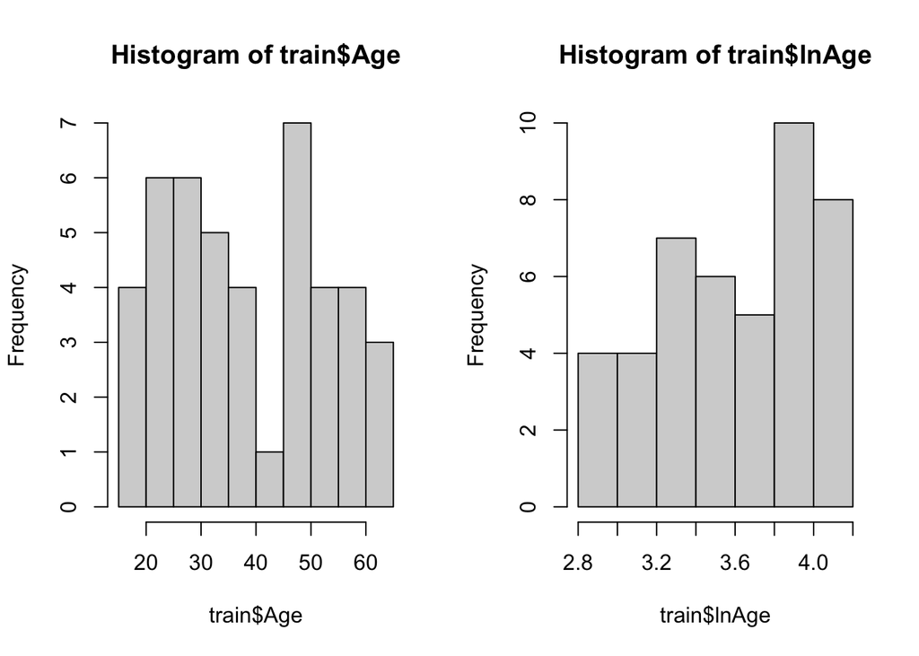

```r
hist(train$Age)
train$lnAge <- log(train$Age)

hist(train$lnAge)
```

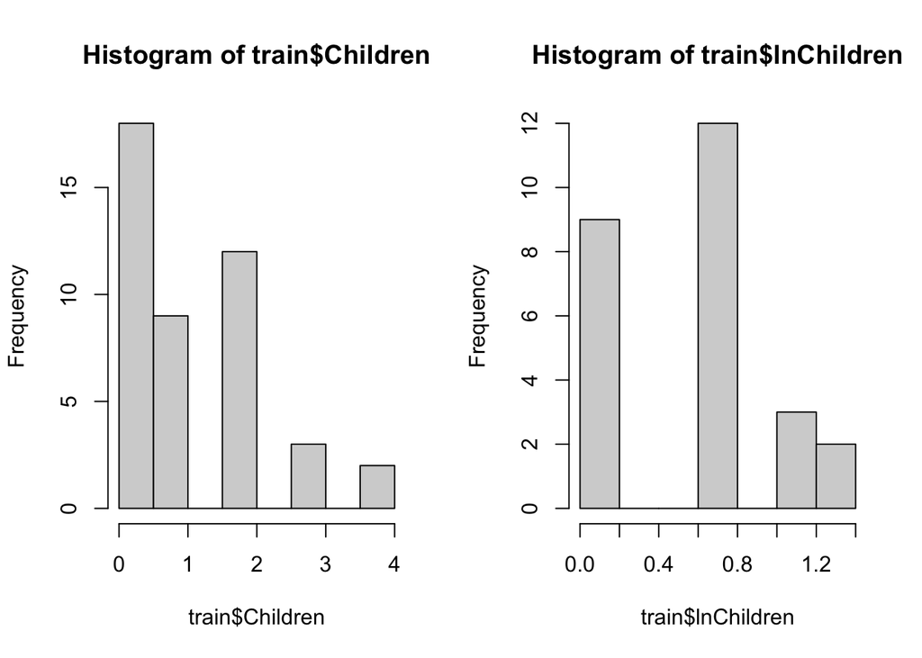

```r
hist(train$Children)
train$lnChildren <- log(train$Children)

hist(train$lnChildren)
```

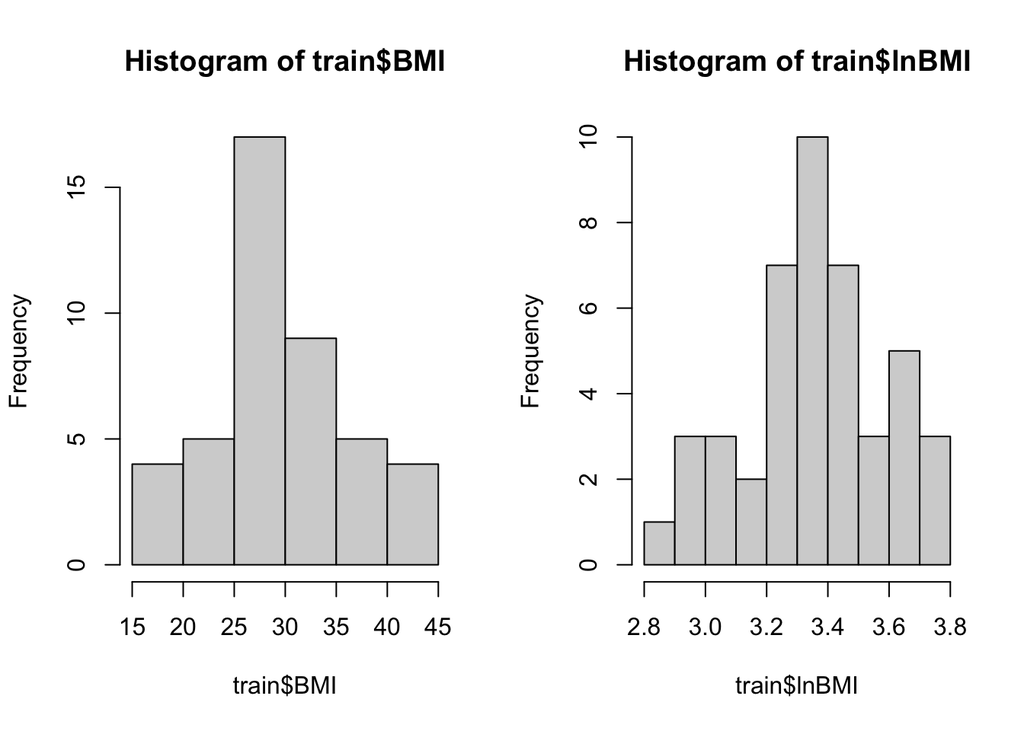

```r
hist(train$BMI)
train$lnBMI <- log(train$BMI)

hist(train$lnBMI)
```

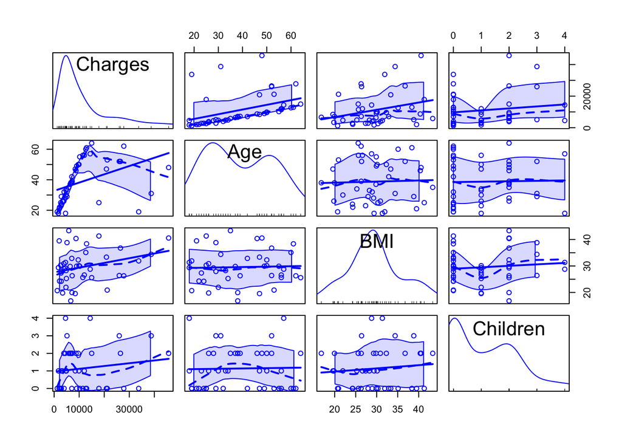

```r
scatterplotMatrix(train[,c(1,2,3,5)])
```

Charges is not normally distributed and Age is a bimodal distribution which violates the third Gauss-Markov assumption because it is not a linear relationship. By transforming the data with a log relationship this will fix the assumption violation.

## Question 4

Implement the solutions from question 3, such as data transformation, along with any other changes you wish. Use the sample data and run a new regression. How have the fit measures changed? How have the signs and significance of the coefficients changed?

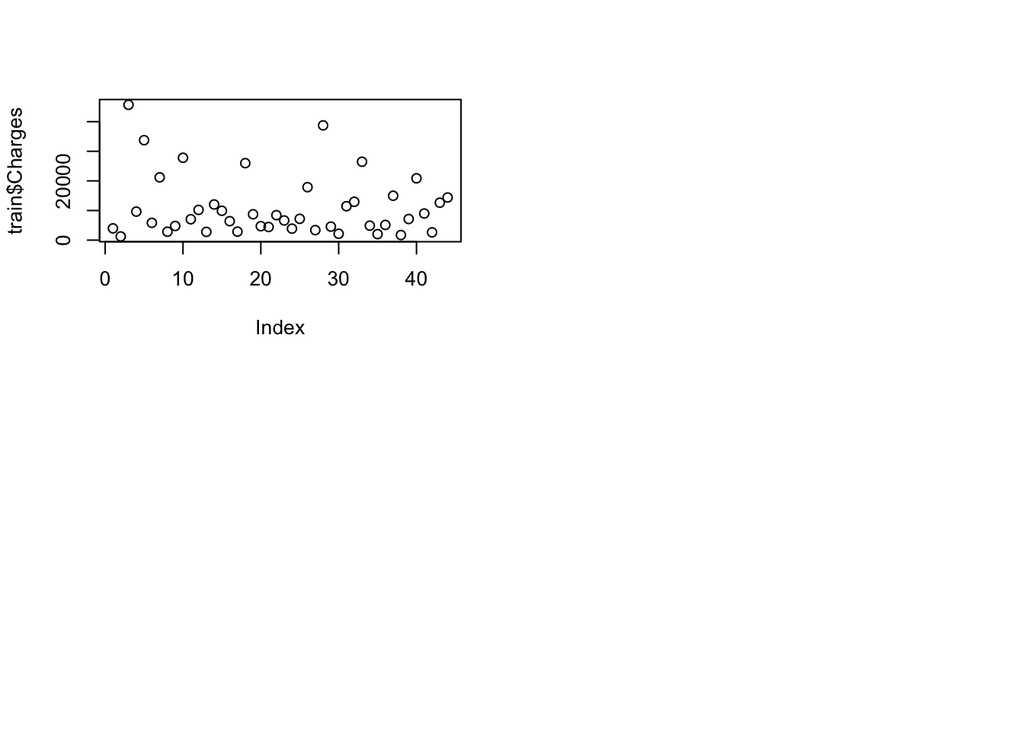

```r
par(mfrow=c(2,2))
plot(train$Charges)

par(mfrow=c(2,2))
```

```r
plot(train$Age)

model_1 <- lm(train$lnCharges ~., data = train[,c(2,3,5,10)] )

summary(model_1)
```

```
##
## Call:
## lm(formula = train$lnCharges ~ ., data = train[, c(2, 3, 5, 10)])
##
## Residuals:
##     Min      1Q  Median      3Q     Max
## -0.8056 -0.3910 -0.1889  0.1363  2.3272
##
## Coefficients:
##             Estimate Std. Error t value Pr(>|t|)
## (Intercept) 6.321946   0.528252  11.968 8.52e-15 ***
## Age         0.040380   0.006997   5.771 9.92e-07 ***
## BMI         0.031654   0.015278   2.072   0.0448 *
## Children    0.106636   0.084141   1.267   0.2124
## ---
## Signif. codes:  0 '***' 0.001 '**' 0.01 '*' 0.05 '.' 0.1 ' ' 1
##
## Residual standard error: 0.6439 on 40 degrees of freedom
## Multiple R-squared:  0.5062, Adjusted R-squared:  0.4691
## F-statistic: 13.67 on 3 and 40 DF,  p-value: 2.782e-06
```

```r
tbl_regression(model_1,
               estimate_fun =  ~style_sigfig(.x, digits = 4)) %>% as_gt() %>%
  gt::tab_source_note(gt::md(paste0("Adjusted R-Squared: ",round(summary(model_1)$adj.r.squared* 100,digits = 2),"%")))
```

| **Characteristic** | **Beta** | **95% CI**<sup>1</sup> | **p-value** |
| --- | --- | --- | --- |
| Age | 0.0404 | 0.0262, 0.0545 | <0.001 |
| BMI | 0.0317 | 0.0008, 0.0625 | 0.045 |
| Children | 0.1066 | -0.0634, 0.2767 | 0.2 |

Adjusted R-Squared: 46.91%  
<sup>1</sup> CI = Confidence Interval

[figure not shown]

```r
par(mfrow=c(2,2))
```

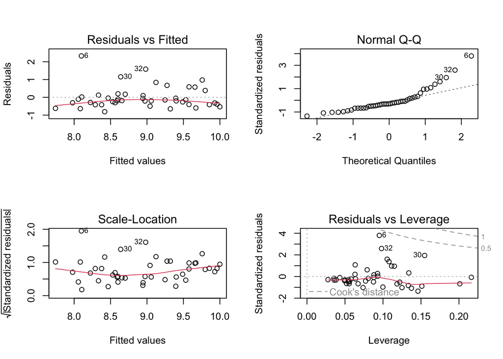

```r
plot(model_1)
```

```r
model_2 <- lm(train$lnAge ~., data = train[,c(2,3,5,11)] )

summary(model_2)
```

```
##
## Call:
## lm(formula = train$lnAge ~ ., data = train[, c(2, 3, 5, 11)])
##
## Residuals:
##      Min       1Q   Median       3Q      Max
## -0.15760 -0.03059  0.01405  0.04902  0.07152
##
## Coefficients:
##               Estimate Std. Error t value Pr(>|t|)
## (Intercept)  2.5348890  0.0515834  49.142   <2e-16 ***
## Age          0.0270857  0.0006833  39.642   <2e-16 ***
## BMI         -0.0001930  0.0014919  -0.129    0.898
## Children     0.0078977  0.0082163   0.961    0.342
## ---
## Signif. codes:  0 '***' 0.001 '**' 0.01 '*' 0.05 '.' 0.1 ' ' 1
##
## Residual standard error: 0.06288 on 40 degrees of freedom
## Multiple R-squared:  0.9753, Adjusted R-squared:  0.9734
## F-statistic: 525.4 on 3 and 40 DF,  p-value: < 2.2e-16
```

```r
tbl_regression(model_2,
               estimate_fun =  ~style_sigfig(.x, digits = 4)) %>% as_gt() %>%
  gt::tab_source_note(gt::md(paste0("Adjusted R-Squared: ",round(summary(model_2)$adj.r.squared* 100,digits = 2),"%")))
```

| **Characteristic** | **Beta** | **95% CI**<sup>1</sup> | **p-value** |
| --- | --- | --- | --- |
| Age | 0.0271 | 0.0257, 0.0285 | <0.001 |
| BMI | -0.0002 | -0.0032, 0.0028 | 0.9 |
| Children | 0.0079 | -0.0087, 0.0245 | 0.3 |

Adjusted R-Squared: 97.34%  
<sup>1</sup> CI = Confidence Interval

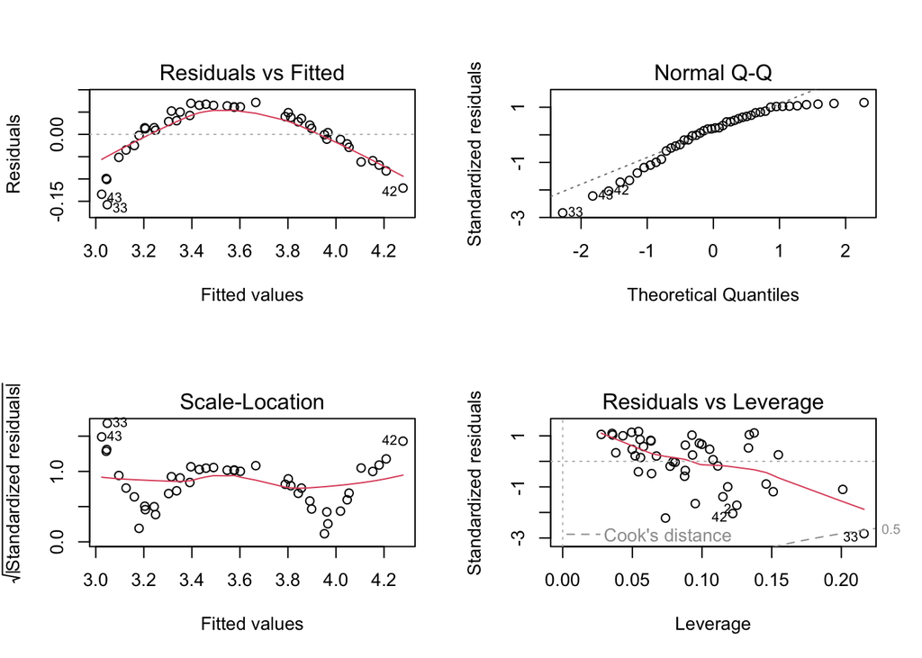

```r
par(mfrow=c(2,2))
plot(model_2)
```